# Practical Machine Learning Course Project

Abel Pardo L?pez

13 de octubre de 2016

## Overview

The objective of this document is to make a model with allow to predict the [Human Activity Recognitiog](http://groupware.les.inf.puc-rio.br/har), of Weight Lifting Exercise. This data consist in several measures of accelerometers in dumbbell, arm, forearm and belt. With this measures is asked to predict the quality of the exercise. The exercises are classified from A to E. Being A exactly according to the specification and B to E different types of errors.

The training data can be dowloaded from https://d396qusza40orc.cloudfront.net/predmachlearn/pml-training.csv The test data that is asked to classify can be downloaded from https://d396qusza40orc.cloudfront.net/predmachlearn/pml-testing.csv

## Clean

In this section it has been explored the data and eliminated the columns and rows that are not useful to the learning and prediction. In following lines are shown the dimensions of the dataset and the column `classe`is factored.

```r
dim(training)
```

```
## [1] 19622   160
```

```r
training$classe<-factor(training$classe)
```

After reviewing the dataset it has been seen a lot of columns with N/A and DIV/0. Most of the corresponds to statiscal data of accellerometer time windows. This data only appears in a maximum of aprox. 4o6 rows from 19622. Therefore it has been eliminated those rows and columns.

```r
training2<-training %>% filter(new_window=="no") %>% select(-X1,-user_name,-new_window,-num_window)
list_stat_index=c(grep("avg",names(training2)),grep("max",names(training2)),grep("min",names(training2)),
                  grep("stddev",names(training2)),grep("skewness",names(training2),"skewness"),
                  grep("kurtosis",names(training2)),grep("var",names(training2)),grep("amplitude",names(training2)),
                  grep("timestamp",names(training2)))
training3<-training2 %>% select(-list_stat_index)
```

Also it hsa been eliminated the variables corresponding to `X1`, `user_name`, `new_window` and `num_window`. Corresponding to row number, dumbbell user, the indication of change of data windows, and the number of data of the window. The last columns than has been eliminated are the related with the `timestamp` because it has not be seen any relationship between the `classe`and the time. A final check has been done to be sure no N/A rows appears.

```r
M<-sapply(training3, function(x) sum(is.na(x)))
M[M>0]
```

```
## magnet_dumbbell_z  magnet_forearm_y  magnet_forearm_z
##                 1                 1                 1
```

```r
training3<-training3 %>% filter(!is.na(magnet_dumbbell_z))%>% filter(!is.na(magnet_forearm_y)) %>% filter(!is.na(magnet_forearm_y))
```

After the review of training data set the same cleaning is done in the test set, to allow the prediction posteriously.

```r
testing2<-testing %>% select(-X1,-user_name,-new_window,-num_window)
testing3<-testing2 %>%select(-list_stat_index)
```

## Explore

After the cleaning of the dataset it can be seen the general statistical properties of the dataset.

```r
summary(training3)
```

```
##    roll_belt        pitch_belt          yaw_belt       total_accel_belt
##  Min.   :-28.90   Min.   :-55.8000   Min.   :-180.00   Min.   : 0.0
##  1st Qu.:  1.10   1st Qu.:  1.7700   1st Qu.: -88.30   1st Qu.: 3.0
##  Median :113.00   Median :  5.2800   Median : -13.20   Median :17.0
##  Mean   : 64.33   Mean   :  0.3014   Mean   : -11.26   Mean   :11.3
##  3rd Qu.:123.00   3rd Qu.: 14.9000   3rd Qu.:  12.85   3rd Qu.:18.0
##  Max.   :162.00   Max.   : 60.3000   Max.   : 179.00   Max.   :29.0
##   gyros_belt_x        gyros_belt_y       gyros_belt_z
##  Min.   :-1.040000   Min.   :-0.64000   Min.   :-1.4600
##  1st Qu.:-0.030000   1st Qu.: 0.00000   1st Qu.:-0.2000
##  Median : 0.030000   Median : 0.02000   Median :-0.1000
##  Mean   :-0.005604   Mean   : 0.03948   Mean   :-0.1306
##  3rd Qu.: 0.110000   3rd Qu.: 0.11000   3rd Qu.:-0.0200
##  Max.   : 2.220000   Max.   : 0.64000   Max.   : 1.6200
##   accel_belt_x       accel_belt_y     accel_belt_z     magnet_belt_x
##  Min.   :-120.000   Min.   :-69.00   Min.   :-275.00   Min.   :-52.00
##  1st Qu.: -21.000   1st Qu.:  3.00   1st Qu.:-162.00   1st Qu.:  9.00
##  Median : -15.000   Median : 34.00   Median :-152.00   Median : 35.00
##  Mean   :  -5.596   Mean   : 30.12   Mean   : -72.48   Mean   : 55.57
##  3rd Qu.:  -5.000   3rd Qu.: 61.00   3rd Qu.:  27.00   3rd Qu.: 59.00
##  Max.   :  85.000   Max.   :164.00   Max.   : 105.00   Max.   :485.00
##  magnet_belt_y   magnet_belt_z       roll_arm         pitch_arm
##  Min.   :354.0   Min.   :-623.0   Min.   :-180.00   Min.   :-88.800
##  1st Qu.:581.0   1st Qu.:-375.0   1st Qu.: -31.60   1st Qu.:-25.900
##  Median :601.0   Median :-319.0   Median :   0.00   Median :  0.000
##  Mean   :593.7   Mean   :-345.5   Mean   :  17.89   Mean   : -4.638
##  3rd Qu.:610.0   3rd Qu.:-306.0   3rd Qu.:  77.30   3rd Qu.: 11.200
##  Max.   :673.0   Max.   : 293.0   Max.   : 180.00   Max.   : 88.500
##     yaw_arm         total_accel_arm  gyros_arm_x        gyros_arm_y
##  Min.   :-180.000   Min.   : 1.00   Min.   :-6.37000   Min.   :-3.4000
##  1st Qu.: -43.100   1st Qu.:17.00   1st Qu.:-1.33000   1st Qu.:-0.8000
##  Median :   0.000   Median :27.00   Median : 0.08000   Median :-0.2400
##  Mean   :  -0.632   Mean   :25.51   Mean   : 0.04295   Mean   :-0.2573
##  3rd Qu.:  45.800   3rd Qu.:33.00   3rd Qu.: 1.56000   3rd Qu.: 0.1400
##  Max.   : 180.000   Max.   :66.00   Max.   : 4.87000   Max.   : 2.8400
##   gyros_arm_z       accel_arm_x       accel_arm_y       accel_arm_z
##  Min.   :-2.3300   Min.   :-404.00   Min.   :-318.00   Min.   :-636.0
##  1st Qu.:-0.0700   1st Qu.:-242.00   1st Qu.: -54.00   1st Qu.:-144.0
##  Median : 0.2300   Median : -44.00   Median :  14.00   Median : -47.0
##  Mean   : 0.2694   Mean   : -60.25   Mean   :  32.64   Mean   : -71.4
```

[output cut: 43 more lines]

```
##  Max.   :79.00       Max.   : 3.9700   Max.   : 6.13000   Max.   : 4.31
##  accel_forearm_x   accel_forearm_y  accel_forearm_z  magnet_forearm_x
##  Min.   :-498.00   Min.   :-632.0   Min.   :-446.0   Min.   :-1280.0
##  1st Qu.:-178.00   1st Qu.:  57.0   1st Qu.:-182.0   1st Qu.: -616.0
##  Median : -57.00   Median : 201.0   Median : -39.0   Median : -377.0
##  Mean   : -61.32   Mean   : 163.9   Mean   : -55.2   Mean   : -312.3
##  3rd Qu.:  77.00   3rd Qu.: 312.0   3rd Qu.:  26.0   3rd Qu.:  -73.0
##  Max.   : 477.00   Max.   : 591.0   Max.   : 291.0   Max.   :  672.0
##  magnet_forearm_y magnet_forearm_z classe
##  Min.   :-896.0   Min.   :-973.0   A:5470
##  1st Qu.:   4.0   1st Qu.: 189.0   B:3718
##  Median : 592.0   Median : 511.0   C:3352
##  Mean   : 380.6   Mean   : 393.4   D:3147
##  3rd Qu.: 737.0   3rd Qu.: 653.0   E:3528
##  Max.   :1480.0   Max.   :1090.0
```

To be sure than the classes are enoughly represented in the dataset and is not required up or down sampling, it has been checked the number of time each class appears.

```r
table(training3$classe) # To know if the data set is equillibred
```

```
##
##    A    B    C    D    E
## 5470 3718 3352 3147 3528
```

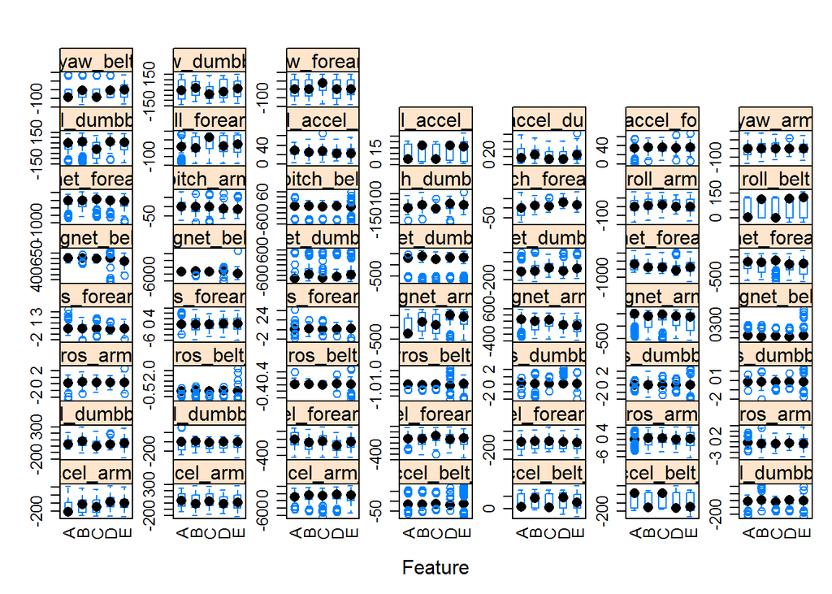

```r
# Box Plot of all variables
set.seed(3141592)
tr4<-sample_n(training3,1000)
p<-featurePlot(x = tr4[, 1:52],
            y = tr4$classe,
            plot = "box",scales=list(y=list(relation="free"),x=list(rot=90)),layout=c(7,8),
            auto.key = list(columns = 5))
print(p)
```

Other plots were done to check than no wrong data was in the dataset. ## Training After the selection of the features, and taking into account the number of rows. It was decide to train with 75 % of the data, and left the 25 % to cross-validate the results.

```r
set.seed(314159)
intrain<-createDataPartition(y=training3$classe,p=0.75,list=FALSE)
trainingSet<-training3[intrain,]
testSet<-training3[-intrain,]
```

The method chosen for the classification was randomforest in part due to it is a good method for multiple classification and in part due to than in the paper [Qualitative Activity Recognition of Weight Lifting Exercises](http://groupware.les.inf.puc-rio.br/work.jsf?p1=11201), than is in the page of the information of project, use a similar approach.

```r
modFit<-train(classe~.,data=trainingSet,method="rf",prox=TRUE)
```

The training is not run to generate this R Markdown due to it took near 7 hour in my computer. The model was saved using following code:

```r
save(modFit,"modelFitRandomForest")
```

And the modelFit is read for the rest of the R Markdow with the following code:

```r
load("modelFitRandomForest")
```

# Predict

After the training is done we have done the cross-validation with the testSet.

```r
result<-predict(modFit,testSet)
confusionMatrix(result,testSet$classe)
```

```
## Confusion Matrix and Statistics
##
##           Reference
## Prediction    A    B    C    D    E
##          A 1367    0    0    0    0
##          B    0  929    1    0    0
##          C    0    0  837    3    0
##          D    0    0    0  783    0
##          E    0    0    0    0  882
##
## Overall Statistics
##
##                Accuracy : 0.9992
##                  95% CI : (0.9979, 0.9998)
##     No Information Rate : 0.2847
##     P-Value [Acc > NIR] : < 2.2e-16
##
##                   Kappa : 0.9989
##  Mcnemar's Test P-Value : NA
##
## Statistics by Class:
##
##                      Class: A Class: B Class: C Class: D Class: E
## Sensitivity            1.0000   1.0000   0.9988   0.9962   1.0000
## Specificity            1.0000   0.9997   0.9992   1.0000   1.0000
## Pos Pred Value         1.0000   0.9989   0.9964   1.0000   1.0000
## Neg Pred Value         1.0000   1.0000   0.9997   0.9993   1.0000
## Prevalence             0.2847   0.1935   0.1745   0.1637   0.1837
## Detection Rate         0.2847   0.1935   0.1743   0.1631   0.1837
## Detection Prevalence   0.2847   0.1937   0.1749   0.1631   0.1837
## Balanced Accuracy      1.0000   0.9999   0.9990   0.9981   1.0000
```

As it can be seen in previous table the results are nearly perfect, with 4 error of the total of 4802 predictions. In following graphs can be seen, checking the error with the number of trees and the variable imporance, than the training time can be improve reducing number of trees and variables.

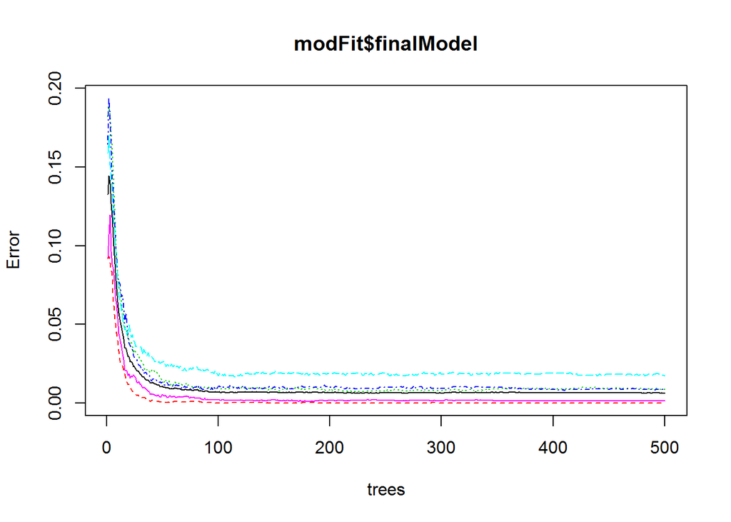

```r
plot(modFit$finalModel)
```

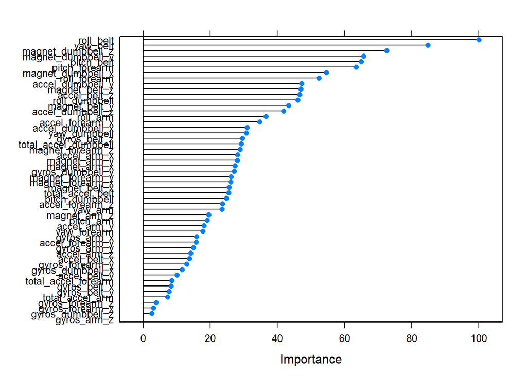

```r
plot(varImp(modFit))
```

# Predict Testing set Finally the result asked values, without classification are obtained:

```r
resultTesting<-predict(modFit,testing3)
resultTesting
```

```
##  [1] B A B A A E D B A A B C B A E E A B B B
## Levels: A B C D E
```